# Capitulo 9 - Estadistica 2

## 9.7 Calculo de la probabilidad de los errores tipo II

En esta sección se describe cómo calcular la probabilidad de cometer un error tipo II en una prueba de hipótesis para la media poblacional. Este procedimiento se ilustra usando el ejemplo del muestreo de aceptación de lotes descrito en la sección 9.6. Las hipótesis nula y alternativa para el número medio de horas de vida útil de un pedido de baterías son: $(H_0: \mu \geq 120)$ y $(H_a: \mu < 120)$. Si $(H_0)$ es rechazada, la decisión será devolver el producto al proveedor, debido a que la media del número de horas de vida útil es menor que la especificada de 120 horas. Si $(H_0)$ no se rechaza, la decisión será aceptar el pedido. Suponga que se usa el nivel de significancia $(\alpha = 0.05)$ para realizar la prueba de hipótesis.

$$ z = \frac{{\bar{x} - \mu_0}}{{\frac{\sigma}{\sqrt{n}}}} = \frac{{\bar{x} - 120}}{{\frac{\sigma}{\sqrt{n}}}} $$

Con base en el método del valor crítico y $z_{0.05} = 1.645$, la regla de rechazo en esta prueba de cola inferior es:

$$Rechazar H_0 si z \leq -1.645$$

Asuma que se seleccionará una muestra de 36 baterías y que por pruebas anteriores se puede considerar que se conoce la desviación estándar poblacional y que su valor es $\sigma = 12$ horas. La regla de rechazo indica que $H_0$ será descartada si:

$$ z = \frac{{\bar{x} - 120}}{{\frac{12}{\sqrt{36}}}} \leq -1.645 $$

Donde $\bar{x}$ es la media de la muestra, $\mu_0$ es la hipótesis nula $\mu_0 = 120$, $\sigma$ es la desviación estándar poblacional $\sigma = 12$, y $n$ es el tamaño de la muestra $n = 36$.

Con esta información, se pueden calcular las probabilidades asociadas con cometer un error tipo II. Primero, recuerde que se comete este error cuando la verdadera media del pedido es menor de 120 horas y se decide aceptar $H_0: \mu \geq 120$. Por tanto, para calcular la probabilidad de cometerlo, se debe elegir un valor de $\mu$ menor que 120 horas.

Por ejemplo, suponga que la calidad del envío es pobre si la vida promedio de las baterías es $\mu = 112$ horas. Si en realidad es verdad que $\mu = 112$, ¿cuál es la probabilidad de aceptar $H_0: \mu \geq 120$ y cometer así un error tipo II? Observamos que es la probabilidad de que la media muestral $x$ sea mayor de 116.71 cuando $\mu = 112$.

$$z = \frac{x - \mu}{\frac{\sigma}{\sqrt{n}}} = \frac{116.71 - 112}{\frac{12}{\sqrt{36}}} = 2.36 $$

La tabla de probabilidad normal estándar indica que para $z = 2.36$, el área en la cola superior es $1.0000 - 0.9909 = 0.0091$. Entonces, $0.0091$ es la probabilidad de cometer un error tipo II cuando $\mu = 112$. Si usamos $\beta$ para denotar la probabilidad de cometer este error, tenemos que si $\mu = 112$, $\beta = 0.0091$. Podemos concluir que si la media de la población es $112$ horas, la probabilidad de incurrir en un error tipo II es solo $0.0091$.

FIGURA 9.8

Probabilidad de un error tipo II cuando $\mu$=112

```python
import numpy as np
import matplotlib.pyplot as plt
from scipy.stats import norm

# Parámetros
n = 36
alpha = 0.05
critical_value = norm.ppf(alpha)

# Valor específico de μ
mu = 112

# Calcular la media y la desviación estándar de la distribución de muestreo
sampling_mean = mu
sampling_std = 12 / np.sqrt(n)

# Generar datos para la distribución de muestreo
x_values = np.linspace(mu - 3 * sampling_std, mu + 3 * sampling_std, 1000)
y_values = norm.pdf(x_values, loc=sampling_mean, scale=sampling_std)

# Calcular el valor z correspondiente a la zona de rechazo
rejection_zone = x_values[x_values >= mu + critical_value * sampling_std]

# Crear la gráfica
fig, ax = plt.subplots()
ax.plot(x_values, y_values, label=f'Distribución de muestreo de $x$, μ = {mu}', color='#009929')
ax.fill_between(rejection_zone, norm.pdf(rejection_zone, loc=sampling_mean, scale=sampling_std), alpha=0.3, label=f'Zona de rechazo, μ = {mu}', color='#D4F8B7')

# Punto específico en la gráfica
plt.scatter([116.71], [0], color='#D4F8B7', marker='o', label='Punto específico (116.71, 0)')

# Anotaciones
plt.annotate(f'$\mu = {mu}$', xy=(mu, 0), xytext=(mu, 0.02), ha='center', arrowprops=dict(facecolor='#D4F8B7', shrink=0.05))

# Etiquetas y título
ax.set_title('Distribución de muestreo de $x$ con Zona de rechazo y Punto Específico', fontsize=14)
ax.set_xlabel('$x$', fontsize=12)
ax.set_ylabel('Densidad de probabilidad', fontsize=12)
ax.legend()

# Cambiar el color de fondo del gráfico
ax.set_facecolor('#d4f8b7')

# Cambiar el color de fondo de la figura
fig.patch.set_facecolor('#D4F8B7')

plt.show()
```

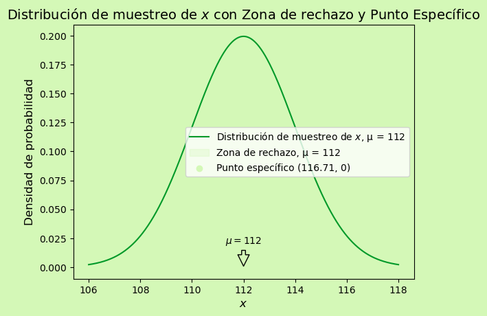

## 9.8 Determinación del tamaño de la muestra en una prueba de hipótesis para la media poblacional

Considera realizar una prueba de hipótesis para el valor de la media poblacional. El nivel de significancia elegido por el usuario determina la probabilidad de cometer un error tipo I en esta prueba. Al controlar el tamaño de la muestra, el usuario también controla la probabilidad de cometer un error tipo II. A continuación se muestra cómo determinar el tamaño de la muestra en la prueba de hipótesis de cola inferior para la media poblacional:

$$c = \mu_0 - z_\alpha \frac{\sigma}{\sqrt{n}}$$

$$ \frac{{\mu_0 - \mu_a}}{{\frac{{z_\alpha}}{{\sqrt{n}}}}} = \frac{{z_\beta}}{{\sqrt{n}}} $$

Al elevar al cuadrado ambos lados de la expresión, obtenemos la fórmula siguiente para el tamaño de la muestra necesario en una prueba de hipótesis de una cola para la media poblacional.

### Tamaño de la Muestra en una Prueba de Hipótesis de una Cola para la Media Poblacional

- $z_\alpha$ = el valor de $z$ que proporciona un área de $\alpha$ en la cola superior de la distribución normal estándar.
- $z_\beta$ = el valor de $z$ que proporciona un área de $\beta$ en la cola superior de la distribución normal estándar.
- $\sigma$ = la desviación estándar poblacional.
- $\mu_0$ = el valor de la media poblacional en la hipótesis nula.
- $\mu_a$ = el valor de la media poblacional utilizado para el error tipo II.

Volviendo al ejemplo del muestreo de aceptación de lotes presentado en las secciones 9.6 y 9.7. Las especificaciones de diseño para el embarque de las baterías indican una vida media útil de por lo menos 120 horas. Los pedidos se regresan si $H_0$ es rechazada: $\mu \geq 120$. Supongamos que el gerente de control de calidad establece las siguientes declaraciones acerca de las probabilidades admisibles de cometer los errores tipo I y tipo II:

### Declaración para el error tipo I:

Si la vida media de las baterías del pedido es $\mu \leq 120$, estoy dispuesto a asumir el riesgo de que la probabilidad de rechazar el embarque sea $\alpha = 0.05$.

### Declaración para el error tipo II:

Si la vida media de las baterías del pedido es 5 horas por debajo de lo que indican las especificaciones (es decir, $\mu = 115$, estoy dispuesto a asumir el riesgo de que la probabilidad de aceptar el embarque sea $\beta = 0.10$.

Estas declaraciones se basan en el criterio del gerente. Otra persona podría establecer diferentes restricciones para las probabilidades. Sin embargo, las declaraciones acerca de las probabilidades admisibles de ambos errores deben establecerse antes de determinar el tamaño de la muestra.

En el ejemplo, $\alpha = 0.05$ y $\beta = 0.10$. Mediante la distribución de probabilidad normal estándar, se tiene $z_{0.05} = 1.645$ y $z_{0.10} = 1.28$.De acuerdo con lo dicho al especificar las probabilidades para los errores, observamos que $\mu_0 = 120$ y $\mu_a = 115$. Por ultimo, supusimos que las desviaciones estandar poblacional se conocia y era $\alpha = 12$.

$$ n = \left(\frac{{(1.645 + 1.28)^2 \cdot (12)^2}}{{(120 - 115)^2}} = 49.3\right) $$

Como las probabilidades de los dos errores tipo I y tipo II se han controlado usando $n = 50$, queda justificado que el gerente de control de calidad utilice las declaraciones $H_0$ es aceptada o $H_0$ es rechazada en esta prueba de hipótesis. Las inferencias correspondientes se hacen teniendo probabilidades admisibles de cometer un error de cualquiera de ambos tipos.

Acerca de la relación entre $\alpha$, $\beta$ y el tamaño $n$ de la muestra caben tres observaciones.

1. Una vez que se tienen dos de estos tres valores, el tercero puede calcularse.
2. Dado un nivel de significancia $\alpha$, aumentando el tamaño de la muestra se reduce $\beta$.
3. Dado un tamaño de muestra, al reducirse $\alpha$ aumenta $\beta$ y al incrementarse $\alpha$, disminuye $\beta$.

La tercera observación debe tenerse en cuenta cuando no se controla la probabilidad de cometer un error tipo II. Dicha observación indica que no se deben elegir niveles de significancia $\alpha$ innecesariamente pequeños. Para un tamaño de muestra dado, elegir un nivel de significancia pequeño implica más riesgo de cometer un error tipo II. Personas con poca experiencia piensan que al realizar una prueba de hipótesis es mejor usar siempre valores pequeños de $\alpha$, lo cual es cierto si la única preocupación es cometer un error tipo I. Sin embargo, los valores pequeños de $\alpha$ tienen la desventaja de incrementar la probabilidad de cometer un error tipo II.

# Ejercicios

## Ejercicio 1

Para resolver este ejercicio, podemos utilizar la fórmula para el tamaño de muestra en una prueba de hipótesis de una cola para la media poblacional. La fórmula es:

$$ n = \left(\frac{(z_\alpha + z_\beta)^2 \cdot \sigma^2}{(\mu_0 - \mu_a)^2}\right) $$

donde:

- $ z_\alpha $ es el valor crítico correspondiente al nivel de significancia $ \alpha $, y como $ \alpha = 0.05 $, entonces $ z_\alpha = -1.645 $ (ya que estamos en la cola inferior),
- $ z_\beta $ es el valor crítico correspondiente a la probabilidad de error tipo II $ \beta $, y como $\beta = 0.10 $, entonces $z_\beta = -1.28 $ (según la información proporcionada),
- $ \sigma $ es la desviación estándar poblacional, que en este caso es $ \sigma = 5 $,
- $ \mu_0 $ es la media bajo la hipótesis nula, que es $ \mu_0 = 10 $,
- $ \mu_a $ es la media bajo la hipótesis alternativa, que es $ \mu_a = 9 $.

FIGURA 9.8

Ejercicio 1

```python
import numpy as np
import matplotlib.pyplot as plt
from scipy.stats import norm

# Parámetros del problema
alpha = 0.05
beta = 0.10
sigma = 5
mu_0 = 10
mu_a = 9

# Valores críticos z_alpha y z_beta
z_alpha = norm.ppf(alpha)
z_beta = norm.ppf(beta)

# Datos para la distribución muestral bajo H0
x_h0 = np.linspace(mu_0 - 4 * sigma, mu_0 + 4 * sigma, 1000)
y_h0 = norm.pdf(x_h0, mu_0, sigma)

# Datos para la distribución muestral bajo Ha
x_ha = np.linspace(mu_a - 4 * sigma, mu_a + 4 * sigma, 1000)
y_ha = norm.pdf(x_ha, mu_a, sigma)

# Crear la gráfica
fig, ax = plt.subplots()
ax.plot(x_h0, y_h0, label=r'$H_0: \mu \geq 10$', color='green')
ax.plot(x_ha, y_ha, label=r'$H_a: \mu < 10$', color='green')

# Marcar los valores críticos

ax.axvline(mu_a + z_beta * sigma, color='green', linestyle='--', label=r'$z_\beta$')

# Establecer el color de fondo
ax.set_facecolor('#d4f8b7')
# Pintar el fondo externo del gráfico
fig.patch.set_facecolor('#D4F8B7')
ax.set_xlabel(r'$\bar{x}$ (Media Muestral)', fontsize=12)

# Agregar información sobre los valores críticos

ax.text(0.76, 0.15, f'$z_{{\\beta}}$ = {z_beta:.2f}', transform=ax.transAxes, fontsize=9, color='green')

# Sombrear las regiones críticas
ax.fill_between(x_h0, y_h0, where=(x_h0 <= mu_0 + z_alpha * sigma), color='green', alpha=0.3)
ax.fill_between(x_ha, y_ha, where=(x_ha <= mu_a + z_beta * sigma), color='green', alpha=0.3)

# Leyenda y etiquetas adicionales
ax.legend()
ax.grid(False)
plt.show()
```

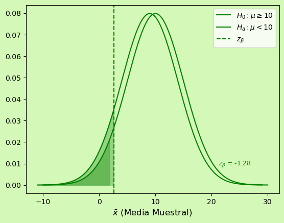